# Lab11

```r
library(tidymodels)
```

```
• Use suppressPackageStartupMessages() to eliminate package startup messages
```

```r
library(tidyverse)
library(GGally)
library(discrim)
```

## Exercise 1

Exercise 1. Let us use iris dataset for practicing classification with `glm() Look at pairwise plots of the first four columns of the dataset by using the column Species for indicating colors. Use the command ggpairs from the library GGally with mapping=aes(color=Species) and columns=1:4 parameters for producing the plots. Based on those plots, should we expect to get good classifiers based on the data?

Form dataset iris_mod by adding variables Species_setosa,Species_virginica and Species_versicolor, which are 1 if observation is from corresponding species and 0 otherwise

Fit a logistic regression model to the variable Species_virginica by using Petal.Length and Petal.Width for regressors.

[output not shown]

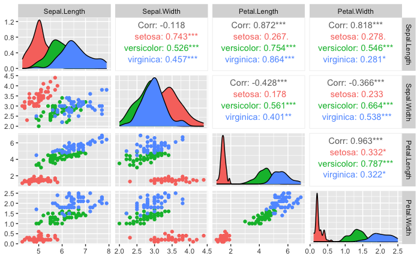

```r
ggpairs(iris, aes(color=Species), columns = 1:4)
```

```r
rec_dummies = recipe(~., data=iris)|> step_dummy(Species, one_hot=TRUE)
iris_mod = rec_dummies|>prep()|>bake(new_data=iris)
iris_mod
```

| Sepal.Length | Sepal.Width | Petal.Length | Petal.Width | Species_setosa | Species_versicolor | Species_virginica |
| --- | --- | --- | --- | --- | --- | --- |
| 5.1 | 3.5 | 1.4 | 0.2 | 1 | 0 | 0 |
| 4.9 | 3.0 | 1.4 | 0.2 | 1 | 0 | 0 |
| 4.7 | 3.2 | 1.3 | 0.2 | 1 | 0 | 0 |
| 4.6 | 3.1 | 1.5 | 0.2 | 1 | 0 | 0 |
| 5.0 | 3.6 | 1.4 | 0.2 | 1 | 0 | 0 |
| 5.4 | 3.9 | 1.7 | 0.4 | 1 | 0 | 0 |
| 4.6 | 3.4 | 1.4 | 0.3 | 1 | 0 | 0 |
| 5.0 | 3.4 | 1.5 | 0.2 | 1 | 0 | 0 |
| 4.4 | 2.9 | 1.4 | 0.2 | 1 | 0 | 0 |
| 4.9 | 3.1 | 1.5 | 0.1 | 1 | 0 | 0 |

[output cut: 140 more lines]

[output not shown]

## Exercise 2

Fitting logistic regression models with tidymodels framework. Fit a logistic regression model to the variable Species_virginica by using Petal.Length, Petal.Width, Sepal.Length, Sepal.Width for regressors by using tidymodels framework. For that, define a new data set iris_mod2, where Species_virginica is changed to a factor variable, use logistic_reg() to define model specification, a recipe indicating outcome and predictors and workflow involving both recipe and model specification. Can we consider this model better than the previous one?

```r
iris_mod2 = recipe(~., data=iris_mod) |> step_bin2factor(starts_with("Species"))|>prep()|>bake(new_data=NULL)
iris_mod2
```

| Sepal.Length | Sepal.Width | Petal.Length | Petal.Width | Species_setosa | Species_versicolor | Species_virginica |
| --- | --- | --- | --- | --- | --- | --- |
| 5.1 | 3.5 | 1.4 | 0.2 | yes | no | no |
| 4.9 | 3.0 | 1.4 | 0.2 | yes | no | no |
| 4.7 | 3.2 | 1.3 | 0.2 | yes | no | no |
| 4.6 | 3.1 | 1.5 | 0.2 | yes | no | no |
| 5.0 | 3.6 | 1.4 | 0.2 | yes | no | no |
| 5.4 | 3.9 | 1.7 | 0.4 | yes | no | no |
| 4.6 | 3.4 | 1.4 | 0.3 | yes | no | no |
| 5.0 | 3.4 | 1.5 | 0.2 | yes | no | no |
| 4.4 | 2.9 | 1.4 | 0.2 | yes | no | no |
| 4.9 | 3.1 | 1.5 | 0.1 | yes | no | no |

[output cut: 140 more lines]

```r
log_reg_spec <- logistic_reg() %>%
  set_engine("glm")

# Recipe
log_reg_recipe <- recipe(Species_virginica ~ Petal.Length + Petal.Width + Sepal.Length + Sepal.Width, data = iris_mod2)

# Workflow
log_reg_workflow <- workflow() %>%
  add_model(log_reg_spec) %>%
  add_recipe(log_reg_recipe)

# Fit model
log_reg_fit <- fit(log_reg_workflow, data = iris_mod2)
glance(log_reg_fit)
```

| null.deviance | df.null | logLik | AIC | BIC | deviance | df.residual | nobs |
| --- | --- | --- | --- | --- | --- | --- | --- |
| 190.9543 | 149 | -5.949273 | 21.89855 | 36.95172 | 11.89855 | 145 | 150 |

[figure not shown]

```r
augment(log_reg_fit, new_data=iris_mod2)|> conf_mat(truth=Species_virginica, estimate=.pred_class)
```

```
          Truth
Prediction yes no
       yes  49  1
       no    1 99
```

```r
augment(log_reg_fit, new_data=iris_mod2)|>mutate(.pred_class=factor(if_else(.pred_yes>1/5,'yes', 'no'), levels=levels(.pred_class))) |> conf_mat(truth=Species_virginica, estimate=.pred_class)
```

```
          Truth
Prediction yes no
       yes  50  4
       no    0 96
```

## Exercise 3

We continue working with iris data set. Fit LDA model for Species in terms of Petal.Length and Petal.Width. How many prediction errors this method makes on training set?

Fit LDA model by using all predictors. What is the number of classifying errors in this case?